# Clustering_Practico_Tetiana_Ianiuk

```python
# import some libraries
import numpy as np
import pandas as pd
import matplotlib as mpl
import matplotlib.pyplot as plt

# seaborn is a layer on top of matplotlib which has additional visualizations -
# just importing it changes the look of the standard matplotlib plots.
# the current version also shows some warnings which we'll disable.
import seaborn as sns
sns.set(style="white", color_codes=True)
import warnings
warnings.filterwarnings("ignore")

# show plots inline
%matplotlib inline
```

### Get Data

```python
# get data and show some records

url = "https://archive.ics.uci.edu/ml/machine-learning-databases/iris/iris.data"
# load dataset into Pandas DataFrame
data = pd.read_csv(url, names=['sepal length','sepal width','petal length','petal width','target'])


#data = data.reset_index(drop = True) # get rid of the Id column - don't need it
data.sample(5)
```

|  | sepal length | sepal width | petal length | petal width | target |
| --- | --- | --- | --- | --- | --- |
| 8 | 4.4 | 2.9 | 1.4 | 0.2 | Iris-setosa |
| 30 | 4.8 | 3.1 | 1.6 | 0.2 | Iris-setosa |
| 67 | 5.8 | 2.7 | 4.1 | 1.0 | Iris-versicolor |
| 24 | 4.8 | 3.4 | 1.9 | 0.2 | Iris-setosa |
| 10 | 5.4 | 3.7 | 1.5 | 0.2 | Iris-setosa |

```python
# split data into features (X) and labels (y)
X = data.iloc[:,0:4]
y = data.iloc[:,-1]

print("\n Caracteristicas \n")
print(X.sample(5))
print("\n Target \n")
print(y.sample(5))
```

```
 Caracteristicas

     sepal length  sepal width  petal length  petal width
38            4.4          3.0           1.3          0.2
64            5.6          2.9           3.6          1.3
29            4.7          3.2           1.6          0.2
77            6.7          3.0           5.0          1.7
110           6.5          3.2           5.1          2.0

 Target

96     Iris-versicolor
28         Iris-setosa
63     Iris-versicolor
9          Iris-setosa
149     Iris-virginica
Name: target, dtype: object
```

### Visualize Data

```python
data["target"].value_counts()
```

```
Iris-setosa        50
Iris-versicolor    50
Iris-virginica     50
Name: target, dtype: int64
```

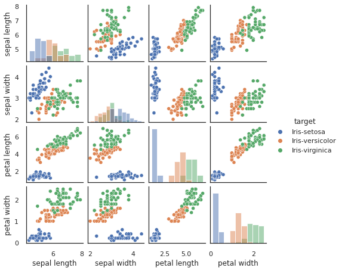

```python
sns.pairplot(data, hue="target", diag_kind="hist", size=1.6);
```

Versicolor y Virginica son muy similares, sera muy dificil generar un algoritmo de clustering que las pueda separar, pero vamos a intentarlo!!

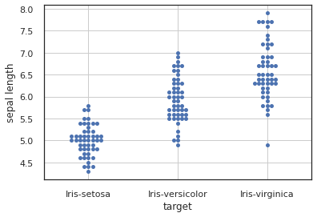

```python
sns.swarmplot(x="target", y="sepal length", data=data)
plt.grid()
```

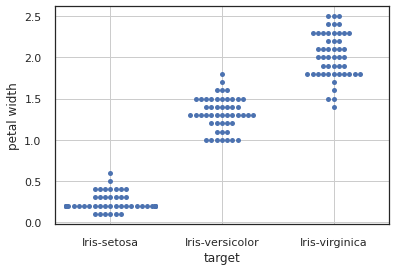

```python
sns.swarmplot(x="target", y="petal width", data=data)
plt.grid()
```

### Feature Scaling

Los datos estan desbalanceados por ejemplo Sepal Lenght es aproximadamente 4 veces mas grande que Petal Width, por lo tando recomiendo escalar los valores. de lo contrario, las características más grandes dominarán a las demás en la agrupación, etc.

# Celda para completar código

```python
from sklearn import preprocessing

scaler = preprocessing.StandardScaler()


#INCORPORAR AQUI LAS LINEAS FALTANTES PARA GENERAR UN DATASET CON LAS CARACTERISITCAS ESCALADAS

X_scaled_array = scaler.fit_transform(X)


X_scaled = pd.DataFrame(X_scaled_array, columns = X.columns)

X_scaled.sample(10)
```

|  | sepal length | sepal width | petal length | petal width |
| --- | --- | --- | --- | --- |
| 89 | -0.416010 | -1.281972 | 0.137236 | 0.133226 |
| 104 | 0.795669 | -0.124958 | 1.160819 | 1.316483 |
| 27 | -0.779513 | 1.032057 | -1.284407 | -1.312977 |
| 80 | -0.416010 | -1.513375 | 0.023504 | -0.129720 |
| 57 | -1.143017 | -1.513375 | -0.260824 | -0.261193 |
| 56 | 0.553333 | 0.569251 | 0.535296 | 0.527645 |
| 123 | 0.553333 | -0.819166 | 0.649027 | 0.790591 |
| 17 | -0.900681 | 1.032057 | -1.341272 | -1.181504 |
| 99 | -0.173674 | -0.587764 | 0.194102 | 0.133226 |
| 11 | -1.264185 | 0.800654 | -1.227541 | -1.312977 |

### Silhouette score & Elbow Method

un valor cercano a +1 indica que la muestra está lejos de los conglomerados vecinos. Un valor de 0 indica que la muestra se encuentra en el límite de decisión entre dos conglomerados vecinos o muy cerca del mismo, y los valores negativos indican que es posible que esas muestras se hayan asignado al conglomerado equivocado.

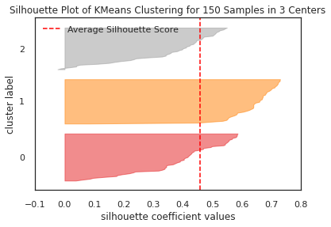

```python
# Instantiate the clustering model and visualizer
#pip install yellowbrick

from sklearn.cluster import KMeans
from yellowbrick.cluster import KElbowVisualizer, SilhouetteVisualizer

nclusters = 3
seed = 0

model = KMeans(n_clusters=nclusters
            , init = 'k-means++'
            , max_iter=500
            , n_init=10
            , random_state=seed)


visualizer = SilhouetteVisualizer(model)

visualizer.fit(X_scaled)    # Fit the data to the visualizer
visualizer.show()    # Draw/show/show the data
```

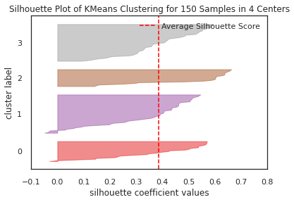

```python
# Instantiate the clustering model and visualizer
#pip install yellowbrick


from sklearn.cluster import KMeans
from yellowbrick.cluster import KElbowVisualizer, SilhouetteVisualizer

nclusters = 4
seed = 0

model = KMeans(n_clusters=nclusters
            , init = 'k-means++'
            , max_iter=500
            , n_init=10
            , random_state=seed)


visualizer = SilhouetteVisualizer(model)

visualizer.fit(X_scaled)    # Fit the data to the visualizer
visualizer.show()    # Draw/show/show the data
```

Se puede observar que con 3 cluster se obtiene un promedio de score de silueta de 0,47 y con 4 clusters un score de 0,39 aproximadamente, por lo tanto se recomienda entrenar un modelo de clustering con 3 clusters

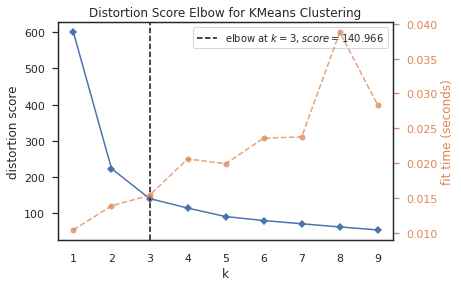

```python
#from sklearn import datasets
from yellowbrick.cluster import KElbowVisualizer

# Instantiate the clustering model and visualizer

seed = 0

km = KMeans(init = 'k-means++'
            , max_iter=500
            , n_init=10
            , random_state=seed)


visualizer = KElbowVisualizer(km, k=(1,10))

visualizer.fit(X_scaled)        # Fit the data to the visualizer
visualizer.show()               # Finalize and render the figure
```

Observamos por el metodo de ELBOW que tenemos que utilizar un K=3 es decir 3 clusters.

### K-Means

Intente agrupar los datos en 4D y ver si puede reproducir los clústeres reales. Es decir, imagine que no tenemos las etiquetas de especies en estos datos y queremos dividir las flores en especies. podría establecer un número arbitrario de grupos e intentar dividirlos en grupos similares. Sabemos que hay 3 especies, así que encontremos 3 especies y veamos si las predicciones para cada punto coinciden con la etiqueta en y, por otro lado sabemos que por el metodo de las siluetas y elbow, la cantidad de clusters recomendada es 3

# Celda para completar código

```python
from sklearn.cluster import KMeans

nclusters = 3
seed = 0

#DESARROLLE AQUI EL METODO DE KMeans utilizando la libreia KMeans.
#
#
#Complete aqui, llamando al metodo de K-means para entrenar el modelo utilizando las variables ncluster y seed
#Utilice X_Scaled para entrenar el modelo
#
#
km = KMeans( n_clusters=nclusters,
              init = 'k-means++'
            , max_iter=500
            , n_init=10
            , random_state=seed)

km.fit(X_scaled)
#
#
#
#
#DESARROLLE AQUI EL METODO DE KMeans utilizando la libreia KMeans.



# predict the cluster for each data point
y_cluster_kmeans = km.predict(X_scaled)





print("\n Caracteristicas \n")
print(X_scaled)

print("\n\n\n Clusters \n")
print(y_cluster_kmeans)
```

```
 Caracteristicas

     sepal length  sepal width  petal length  petal width
0       -0.900681     1.032057     -1.341272    -1.312977
1       -1.143017    -0.124958     -1.341272    -1.312977
2       -1.385353     0.337848     -1.398138    -1.312977
3       -1.506521     0.106445     -1.284407    -1.312977
4       -1.021849     1.263460     -1.341272    -1.312977
..            ...          ...           ...          ...
145      1.038005    -0.124958      0.819624     1.447956
146      0.553333    -1.281972      0.705893     0.922064
147      0.795669    -0.124958      0.819624     1.053537
148      0.432165     0.800654      0.933356     1.447956
149      0.068662    -0.124958      0.762759     0.790591

[150 rows x 4 columns]



 Clusters

[1 1 1 1 1 1 1 1 1 1 1 1 1 1 1 1 1 1 1 1 1 1 1 1 1 1 1 1 1 1 1 1 1 1 1 1 1
 1 1 1 1 1 1 1 1 1 1 1 1 1 2 2 2 0 0 0 2 0 0 0 0 0 0 0 0 2 0 0 0 0 2 0 0 0
 0 2 2 2 0 0 0 0 0 0 0 2 2 0 0 0 0 0 0 0 0 0 0 0 0 0 2 0 2 2 2 2 0 2 2 2 2
 2 2 0 0 2 2 2 2 0 2 0 2 0 2 2 0 2 2 2 2 2 2 0 0 2 2 2 0 2 2 2 0 2 2 2 0 2
 2 0]
```

### Principal Component Analysis (PCA)

Si tiene muchas característics, puede ser útil reducir algunas características, para evitar la maldición de la dimensionalidad (es decir, necesitar exponencialmente más datos para hacer predicciones precisas a medida que crece la cantidad de características). Puede hacer esto con el análisis de componentes principales (PCA), que reasigna los datos a un nuevo sistema de coordenadas (más pequeño) que trata de dar cuenta de la mayor información posible. puedes *también* usar PCA para visualizar los datos al reducir las # características a 2 dimensiones y hacer un diagrama de dispersión.

En este caso recomiendo usar PCA para poder visualizar los datos, ya entrenamos el modelo de K-means y tenemos los clusters identificados, ahora transformemos de 4D a 2D las caracteristicas. para solo visualizarlas en un grafico, y poder observar los CLUSTERS.

# Celda para completar código

```python
from sklearn.decomposition import PCA

ndimensions = 2


#Aplique un algoritmo de PCA en X_scaled, para pasar de 4 a 2 dimensiones, puede utilizar la variable ndimension
#
#
pca = PCA(n_components=ndimensions)
# pca.fit(???)
X_pca_array = pca.fit_transform(X_scaled)

#
#
#Aplique un algoritmo de PCA en X_scaled, para pasar de 4 a 2 dimensiones, puede utilizar la variable ndimension

X_pca = pd.DataFrame(X_pca_array, columns=['principal component 1','principal component 2'])


print(X_pca.sample(10))
explained_variance = pca.explained_variance_ratio_
print("\n\n explained_variance")
print(explained_variance)
```

```
     principal component 1  principal component 2
142               1.153190              -0.701326
93               -0.373628              -2.017932
20               -1.914556               0.430465
81                0.014118              -1.573392
4                -2.388777               0.674767
13               -2.639716              -0.938282
54                1.072594              -0.211758
50                1.103994               0.863112
18               -1.894074               1.431111
62                0.551634              -1.772582


 explained_variance
[0.72770452 0.23030523]
```

Tenemosnuevas coordenadas 2D para cada punto de datos. En este punto, si no tiene datos etiquetados, puede agregar los ID de clúster de k-means a esta tabla y hacer un diagrama de dispersión de colores. en realidad tenemos etiquetas para los puntos de datos, pero imaginemos que no las tenemos, y usemos las etiquetas pronosticadas para ver cómo se ven las predicciones.

```python
finalDf = pd.concat([X_pca, data[['target']]], axis = 1)
finalDf.head()

finalDf['ClusterKmeans'] = y_cluster_kmeans
finalDf.sample(10)
```

|  | principal component 1 | principal component 2 | target | ClusterKmeans |
| --- | --- | --- | --- | --- |
| 110 | 1.365909 | 0.693948 | Iris-virginica | 2 |
| 146 | 1.558492 | -0.905314 | Iris-virginica | 0 |
| 48 | -2.226781 | 1.025483 | Iris-setosa | 1 |
| 29 | -2.268790 | -0.314879 | Iris-setosa | 1 |
| 145 | 1.870522 | 0.382822 | Iris-virginica | 2 |
| 74 | 0.700473 | -0.063494 | Iris-versicolor | 0 |
| 40 | -2.286527 | 0.467992 | Iris-setosa | 1 |
| 61 | 0.438730 | -0.058881 | Iris-versicolor | 0 |
| 67 | 0.153393 | -0.790725 | Iris-versicolor | 0 |
| 92 | 0.330005 | -0.988901 | Iris-versicolor | 0 |

### Grafica de Dispersion (TARGET)

En esta grafica visualizaremos todos los puntos, en donde los ejes son los componentes principales obtenidos de aplicar PCA al dataset escalado, y cada punto se visualizara pintado con colores asociados a la etiqueta o target, ya que partimos de un dataset etiquetado.

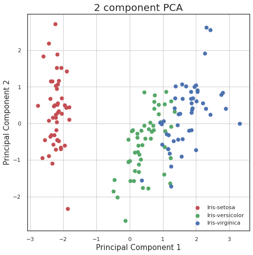

```python
fig = plt.figure(figsize = (8,8))
ax = fig.add_subplot(1,1,1)
ax.set_xlabel('Principal Component 1', fontsize = 15)
ax.set_ylabel('Principal Component 2', fontsize = 15)
ax.set_title('2 component PCA', fontsize = 20)
targets = ['Iris-setosa', 'Iris-versicolor', 'Iris-virginica']
colors = ['r', 'g', 'b']
for target, color in zip(targets,colors):
    indicesToKeep = finalDf['target'] == target
    ax.scatter(finalDf.loc[indicesToKeep, 'principal component 1']
               , finalDf.loc[indicesToKeep, 'principal component 2']
               , c = color
               , s = 50)
ax.legend(targets)
ax.grid()
```

### Grafica de Dispersion (CLUSTERS)

En esta grafica visualizaremos todos los puntos, en donde los ejes son los componentes principales obtenidos de aplicar PCA al dataset escalado, y cada punto se visualizara pintado con colores asociados al CLUSTER obtenido luego de aplicar K-MEANS, como se puede comparar con los datos etiquetados, los clusters se ASEMEJAN BASTANTE.

Un mecanismo asi puede ser utilizado para etiquetar flores, cuando no tenemos la etiqueta de antemano, incluso nos puede servir para generar clasificaciones mas especificas.

Como aclaramos desde el principio, la division entre Versicolor y Virginica es muy fina, y en ambos graficos es costoso encontrar una division clara.

La division real, basada en los datos etiquetados de antemano, es por una linea VERTICAL al medio del conjunto de datos, en cambio segun K-means, la division es por una linea horizontal a traves de los datos.

En estos casos la realidad difiere un poco, de lo que establece un algoritmo matematico. Seguramente para obtener una mejor division sea necesario contar con mas caracteristicas.

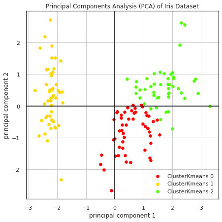

```python
# so now we can make a 2d scatterplot of the clusters
# first define a plot fn

def plotData(df, groupby):
    "make a scatterplot of the first two principal components of the data, colored by the groupby field"

    # make a figure with just one subplot.
    # you can specify multiple subplots in a figure,
    # in which case ax would be an array of axes,
    # but in this case it'll just be a single axis object.
    fig, ax = plt.subplots(figsize = (7,7))

    # color map
    cmap = mpl.cm.get_cmap('prism')

    # we can use pandas to plot each cluster on the same graph.
    # see http://pandas.pydata.org/pandas-docs/stable/generated/pandas.DataFrame.plot.html
    for i, cluster in df.groupby(groupby):
        cluster.plot(ax = ax, # need to pass this so all scatterplots are on same graph
                     kind = 'scatter',
                     x = 'principal component 1', y = 'principal component 2',
                     color = cmap(i/(nclusters-1)), # cmap maps a number to a color
                     label = "%s %i" % (groupby, i),
                     s=30) # dot size
    ax.grid()
    ax.axhline(0, color='black')
    ax.axvline(0, color='black')
    ax.set_title("Principal Components Analysis (PCA) of Iris Dataset");

# plot the clusters each datapoint was assigned to
plotData(finalDf, 'ClusterKmeans')
```

## Introduzca una conclusión de los resultados obtenidos

```python
#CONCLUSION DEL ANALISIS DESARROLLADO:

#BASICAMENTE NO MUCHO MAS HAY QUE DECIR. PUES EL K-MEANS TIENE LA TENDENCIA DE FORMAR CLASTERS REDONDOS, AHORA VEMOS EN PRACTICA ALGO QUE SE NOS HABIA DICHO EN LA CLASE.
#Y PARA UNA SEPARACION MEJOR CON K-MEANS SERIA DESEABLE TENER ALGUNA CARACTERISTICA VARIABLE QUE SEPARE MAS CLUSTERS DE LA VIRGUNICA Y VERSICOLOR(ROJO Y VERDE).

#SEGURAMENTE QUE CON OTROS ALGORITMOS TAMPOCO HABRA UNA MANERA MUY BUENA MANERA DE DETECTAR LOS CLUSTERS DE MANERA QUE COINCIDAN IDEALMENTE CON LAS ETIQUETAS REALES.
#Y SIN EMBARGO, SUPONGO QUE AOLICANDO PRIMERO EL PCA O UNA TRANSFORMACION DE KERNEL ANTES DE PASAR EL K-MEANS PODRIA AYUDAR A DIFERIR MAS LOS DOS CLUSTERS MECIONADOS.
```

```python
from sklearn.kernel_approximation import RBFSampler

# Aplicamos la transformación de kernel RBF
rbf_feature = RBFSampler(gamma=1, n_components=100, random_state=1)
X_rbf = rbf_feature.fit_transform(X_scaled)

# Mostramos los primeros cinco datos transformados con el kernel RBF
print('Datos transformados con kernel RBF:')
print(X_rbf[:5, :])
```

[output not shown]

[output cut: 31 more lines]

[output not shown]

```python
# Corremos el algoritmo K-Means con el kernel RBF
kmeans_rbf = KMeans(n_clusters=3, init='k-means++', random_state=1)
kmeans_rbf.fit(X_rbf)

# Imprimimos las etiquetas de los clusters
kmeans_rbf.labels_
print('Etiquetas de los clusters con kernel RBF:')
print(kmeans_rbf.labels_)
```

```
Etiquetas de los clusters con kernel RBF:
[1 1 1 1 1 1 1 1 1 1 1 1 1 1 1 1 1 1 1 1 1 1 1 1 1 1 1 1 1 1 1 1 1 1 1 1 1
 1 1 1 1 0 1 1 1 1 1 1 1 1 2 2 2 0 0 0 2 0 0 0 0 0 0 0 0 2 0 0 0 0 2 0 0 0
 0 0 0 2 0 0 0 0 0 0 0 2 2 0 0 0 0 0 0 0 0 0 0 0 0 0 2 0 2 2 2 2 0 2 0 2 2
 0 2 0 2 2 2 0 2 0 2 0 2 0 2 2 0 2 2 2 2 0 2 0 0 2 2 2 2 2 2 2 0 2 2 2 0 2
 2 2]
```

```python
finalDf['ClusterRBFKmeans'] = kmeans_rbf.labels_
finalDf.sample(10)
```

|  | principal component 1 | principal component 2 | target | ClusterKmeans | ClusterRBFKmeans |
| --- | --- | --- | --- | --- | --- |
| 10 | -2.163487 | 1.070596 | Iris-setosa | 1 | 1 |
| 59 | 0.004968 | -1.029401 | Iris-versicolor | 0 | 0 |
| 55 | 0.384458 | -0.591062 | Iris-versicolor | 0 | 0 |
| 6 | -2.445711 | 0.074563 | Iris-setosa | 1 | 1 |
| 141 | 1.903117 | 0.686025 | Iris-virginica | 2 | 2 |
| 149 | 0.959299 | -0.022284 | Iris-virginica | 0 | 2 |
| 0 | -2.264542 | 0.505704 | Iris-setosa | 1 | 1 |
| 61 | 0.438730 | -0.058881 | Iris-versicolor | 0 | 0 |
| 62 | 0.551634 | -1.772582 | Iris-versicolor | 0 | 0 |
| 142 | 1.153190 | -0.701326 | Iris-virginica | 0 | 0 |

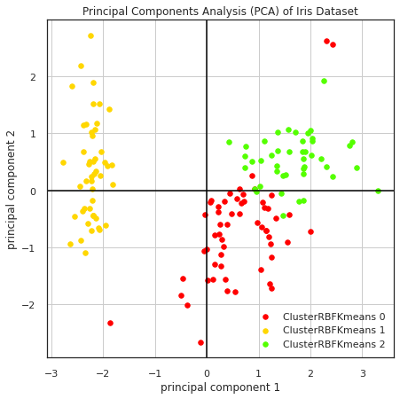

```python
# plot the clusters each datapoint was assigned to
plotData(finalDf, 'ClusterRBFKmeans')
```

```python
from pandas.core.base import value_counts
print('Distribucion original de clusters')
print(data[['target']].value_counts())

print('\n Distribucion de clusters K-means')
print(finalDf[['ClusterKmeans']].value_counts())

print('\n Distribucion de clusters K-means despues de transformacion RBF kernel')
print(finalDf[['ClusterRBFKmeans']].value_counts())
```

```
Distribucion original de clusters
target
Iris-setosa        50
Iris-versicolor    50
Iris-virginica     50
dtype: int64

 Distribucion de clusters K-means
ClusterKmeans
0                53
1                50
2                47
dtype: int64

 Distribucion de clusters K-means despues de transformacion RBF kernel
ClusterRBFKmeans
0                   57
1                   49
2                   44
dtype: int64
```

```python
#VEMOS QUE EL INTENTO DE REALIZAR UNA TRANSFORMACION PREVIA DE DATOS CON EL KERNEL RBF HA DADO PEORES
#RESULTADOS, POR LO MENOS CON EL PARAMETRO GAMMA = 1 Y BUSCAR EL VALOR MAS ADECUADO SERIA COMPUTACIONALMENTE COSTOSO Y
#LUEGO DUDO QUE LAS METRICAS DE SCORING DISPONIBLES PARA COMPARACION (SI USO UN GridSearch O RandomizedSearchCV) DEN ENCUENTREN
#REALMENTE EL MEJOR PARAMETRO GAMMA DEBIDO A QUE NUESTROS CLUSTERS REALES ESTAN  INCLINADAS DIAGONALMENTE Y MUY CERCANAS..
#EN ESTE CASO EL METODO DE SILOUHETTE O SUMA DE CUADRADOS DENTRO DE CADA CLUSTER NOS DEBERIAN LOS PARAMETROS A OPTIMIZAR.
```

```python
#MEJOR PRUEBO CON GAUSSIANMIXTURE, PORQUE SEGUN LA ILUSTRACION DE LOS MODELOS
#DISPONIBLES EN EL sklearn DEBE DETECTAR MEJOR LOS CLUSTERES LARGOS E INCLINADOS, COMO ES NUESTRO CASO AHORA.
#OREA OPCION PODRIA SER EL DBSCAN, PERO TIENE DOS PARAMETROS A AFINAR Y NO PUEDE RECIBIR LA CANTIDAD DE CLASES
#A DETECTAR Y ES ALGO QUE YA SABEMOS DESPUES DE ANALISAR EL K-MEANS Y PODEMOS APROVECHAR.
```

```python
from sklearn.mixture import GaussianMixture

# Creación del modelo Gaussian Mixture
gmm = GaussianMixture(n_components=3, random_state=0)

# Entrenamiento del modelo
gmm.fit(X_scaled)

# Asignación de etiquetas a cada punto
gmm_labels = gmm.predict(X_scaled)
finalDf['Gmm_labels'] = gmm_labels
finalDf.tail(10)
```

|  | principal component 1 | principal component 2 | target | ClusterKmeans | ClusterRBFKmeans | Gmm_labels |
| --- | --- | --- | --- | --- | --- | --- |
| 140 | 2.016157 | 0.610397 | Iris-virginica | 2 | 2 | 2 |
| 141 | 1.903117 | 0.686025 | Iris-virginica | 2 | 2 | 2 |
| 142 | 1.153190 | -0.701326 | Iris-virginica | 0 | 0 | 2 |
| 143 | 2.043308 | 0.864685 | Iris-virginica | 2 | 2 | 2 |
| 144 | 2.001691 | 1.048550 | Iris-virginica | 2 | 2 | 2 |
| 145 | 1.870522 | 0.382822 | Iris-virginica | 2 | 2 | 2 |
| 146 | 1.558492 | -0.905314 | Iris-virginica | 0 | 0 | 2 |
| 147 | 1.520845 | 0.266795 | Iris-virginica | 2 | 2 | 2 |
| 148 | 1.376391 | 1.016362 | Iris-virginica | 2 | 2 | 2 |
| 149 | 0.959299 | -0.022284 | Iris-virginica | 0 | 2 | 2 |

```
Distribucion original de clusters
target
Iris-setosa        50
Iris-versicolor    50
Iris-virginica     50
dtype: int64

 Distribucion de clusters K-means
ClusterKmeans
0                53
1                50
2                47
dtype: int64

 Distribucion de clusters K-means despues de transformacion RBF kernel
ClusterRBFKmeans
0                   57
1                   49
2                   44
dtype: int64

 Distribucion de clusters K-means despues de transformacion RBF kernel
Gmm_labels
2             55
0             50
1             45
dtype: int64
```

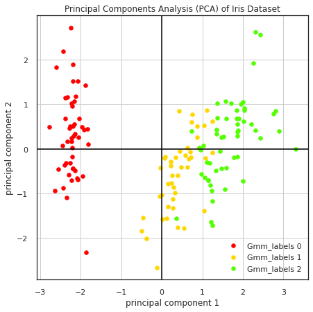

```python
# plot the clusters each datapoint was assigned to
plotData(finalDf, 'Gmm_labels')

#Comparacion de cantidad de observaciones de cada cluster
print('Distribucion original de clusters')
print(data[['target']].value_counts())

print('\n Distribucion de clusters K-means')
print(finalDf[['ClusterKmeans']].value_counts())

print('\n Distribucion de clusters K-means despues de transformacion RBF kernel')
print(finalDf[['ClusterRBFKmeans']].value_counts())

print('\n Distribucion de clusters K-means despues de transformacion RBF kernel')
print(finalDf[['Gmm_labels']].value_counts())
```

```python
finalDf.head(4) #se ve que la codificacion de Gmm no coincide con el resto de modelos
```

|  | principal component 1 | principal component 2 | target | ClusterKmeans | ClusterRBFKmeans | Gmm_labels |
| --- | --- | --- | --- | --- | --- | --- |
| 0 | -2.264542 | 0.505704 | Iris-setosa | 1 | 1 | 0 |
| 1 | -2.086426 | -0.655405 | Iris-setosa | 1 | 1 | 0 |
| 2 | -2.367950 | -0.318477 | Iris-setosa | 1 | 1 | 0 |
| 3 | -2.304197 | -0.575368 | Iris-setosa | 1 | 1 | 0 |

```python
#Si calculo solo la cantidad que entra a cada cluster(colo lo hice antes), el K-means y GaussianMixture parecen ir a la par,
#pero voy a vuscar la forma de comparar por fila (por observacion) cuantas ha acertado cada de uno de los modelos.
```

```python
#Gmm modelo hay que recodificar los clusters para que councida con el resto , tambien ha de codificar el target
```

```python
#Chequeo por fila si councide con la etiqueta original
finalDf.target.replace({"Iris-setosa": 1, "Iris-versicolor": 0, "Iris-virginica": 2}, inplace = True)
finalDf.Gmm_labels.replace({1: 0, 0: 1}, inplace = True)
```

```python
finalDf.head(4)
```

|  | principal component 1 | principal component 2 | target | ClusterKmeans | ClusterRBFKmeans | Gmm_labels |
| --- | --- | --- | --- | --- | --- | --- |
| 0 | -2.264542 | 0.505704 | 1 | 1 | 1 | 1 |
| 1 | -2.086426 | -0.655405 | 1 | 1 | 1 | 1 |
| 2 | -2.367950 | -0.318477 | 1 | 1 | 1 | 1 |
| 3 | -2.304197 | -0.575368 | 1 | 1 | 1 | 1 |

```python
#por si a caso igualamos tipo de datos en las columnas a trabajar
finalDf = finalDf.astype({"target": "Int64", "ClusterKmeans": "Int64", "ClusterRBFKmeans": "Int64", "Gmm_labels": "Int64"})
#extraer valores únicos(clusters) de la columna target y contar coincidencias en la columna correspondiente al modelo
def acierto(finalDf, modelname):
  for valor_unico in finalDf['target'].unique():
      conteo = 0
      for index, row in finalDf.iterrows():
          if row['target'] == valor_unico and row['target'] == row[modelname]:
              conteo += 1
      print(f"Cluster {valor_unico} - Coincidencias: {(conteo/50)*100}% de 50")
```

```python
print("Aciertos de Kmeans")
acierto(finalDf, modelname = "ClusterKmeans")
print("\n Aciertos de ClusterRBFKmeans")
acierto(finalDf, modelname = "ClusterRBFKmeans")
print("\n Aciertos de Gmm_labels")
acierto(finalDf, modelname = "Gmm_labels")
print("\n Aciertos de target, control del algoritmo")
acierto(finalDf, modelname = "target") #control
```

```
Aciertos de Kmeans
Cluster 1 - Coincidencias: 100.0% de 50
Cluster 0 - Coincidencias: 78.0% de 50
Cluster 2 - Coincidencias: 72.0% de 50

 Aciertos de ClusterRBFKmeans
Cluster 1 - Coincidencias: 98.0% de 50
Cluster 0 - Coincidencias: 82.0% de 50
Cluster 2 - Coincidencias: 70.0% de 50

 Aciertos de Gmm_labels
Cluster 1 - Coincidencias: 100.0% de 50
Cluster 0 - Coincidencias: 90.0% de 50
Cluster 2 - Coincidencias: 100.0% de 50

 Aciertos de target, control del algoritmo
Cluster 1 - Coincidencias: 100.0% de 50
Cluster 0 - Coincidencias: 100.0% de 50
Cluster 2 - Coincidencias: 100.0% de 50
```

```python
#AHORA SE PUEDE COMPARAR LOS MODELOS Y OBSERVAMOS QUE LA GAUSSIAN MIXTURE FUNCIONA MEJOR DE TODAS QUE SE HAN EMPLEADO
#ENTIENDO QUE CAPTA MEJOR LAS RELACIONES ENTRE LAS VARIABLES DEBIDO A QUE DISTRUBUCION DE GAUSS ES MAS CERCANA A LOS PROCESOS NATURALES
#MI SUPOSICION ES QUE DBSCAN NO DARIA UN EFECTO IGUAL DE BUENO DBIDO A QUE SE ENFOCA EN LA DENCIDAD Y YA EN EL GRAFICO DE PAIRPLOT SE VEIA
#QUE LA DENSIDAD DE LOS CLASTERES 0 Y 2 (VERSICOLOR Y VIRGINICA) SON IGUAL DE DENSAS.
```